# Chapter 1, pt. 2 Problem Notes

# Chapter 1, pt. 2 Problem Notes

1.9. Here, I’ve entered and generated the data for you:

```r
pop <- c(3278, 3347, 3417, 3486, 3558, 3632, 3708, 3785, 3861, 3936, 4011, 4084, 4156, 4226, 4298, 4372, 4447, 4522, 4601, 4682, 4762, 4844, 4927, 5013, 5099, 5185, 5273, 5357, 5440, 5521, 5601, 5681, 5762, 5840, 5918, 5995, 6072, 6147, 6222, 6297, 6373, 6449)

years <- seq(from = 1964, to = 2005, by = 1)
```

1.10. Eyeballing or fitting a line is fine.

1.11. None.

1.12. None.

1.13. Try to find this analytically if you can. If not, then estimate what the value would be in terms of $K$.

1.16. By “exponential map,” the authors mean “logistic map.” Use a loop through your 50 time steps. Place all values of $\lambda$ on the same graph by using the function `lines(x = , y = )`.

1.18. **No spreadsheet!** :) Simply plot the three models with the three parameters listed using R. Use an initial value of $N_0 = 0.05$ and run for 25 time steps.  
We didn’t have lab this week and I was going to teach you what a “loop” is and how to do one in R. In sum, it’s a way to iterate processes; i.e., it does work for you to make your work easier. For discrete-time problems, remember how in the first problem set (1.1) you found the population size at $N_{t+1}$, then took $N_{t+1}$ and used that to calculate $N_{t+2}$, over and over? Well, this is exactly how loops work: they would have found all of your $N$s by iteracing the the equation over each subsequent $N$. I am not going to use this section to teach you loop: I will do that next week. For the time being, however, I would like for you to take the block of code below for the Hassell model and modify it to do all of 1.8 (i.e., including the other two models). I believe you can do it: if you have any questions or problems, them please reach out.

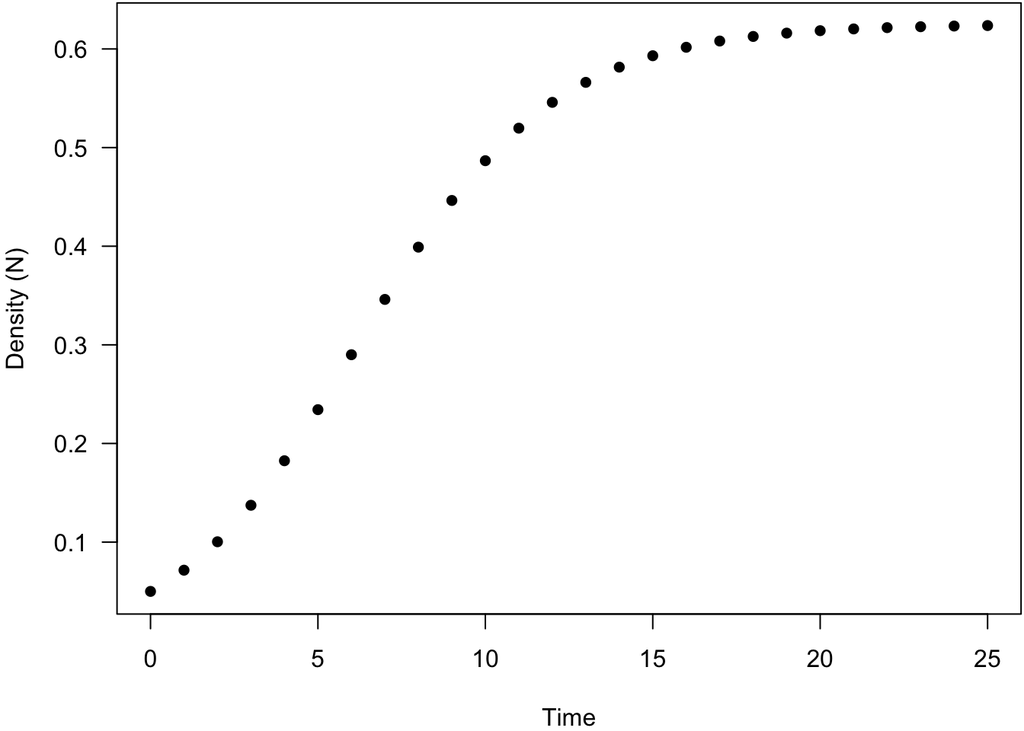

```r
# Write the function
Hassell <- function(N0, lambda, alpha, beta) {
  Nt1 <- lambda*N0/((1 + alpha*N0)^beta)
  return(Nt1)
}

# Set population size at step 0
  N0 <- 0.05
# Create a vector of time steps and corresponding vector to sote N values
  steps <- 25
  time_seq <- 0:steps
  N_vec <- vector(mode = "numeric", length = (steps + 1))
# Set N at step 0 to N0
  N_vec[1] <- N0
# Iteratively calculate N
  for (i in 1:(steps)) {
    Nt <- N_vec[i]
    Nt1 <- Hassell(N0 = Nt, lambda = 1.5, alpha = 2, beta = 0.5)
    N_vec[i + 1] <- Nt1
  }

# Plot your results (`par()` here is reducing the whitespace around the plot)
  par(mar = c(4, 4, 0.1, 0.1), oma = c(0, 0, 0, 0))
  plot(x = time_seq, y = N_vec, las = 1, xlab = "Time", ylab = "Density (N)", type = "p", lwd = 2, pch = 16)
```